# Deterministic sensitivity analysis

2016-09-16

# Introduction

The objective of deterministic sensitivity analysis is to assess how cost is sensitive to parameter values. Parameter values are changed individually (usually through upper and lower bounds) and the results on cost are reported.

Sensitivity analysis is distinct from probabilistic uncertainty analysis: whereas in uncertainty analysis the objective is to account for uncertainty on parameter values in estimating model results, in sensitivity analysis the objective is to assess the sensitivity of results to variations of individual parameters.

Both analyses are complementary. Uncertainty analysis is essential to decision making, while sensitivity analysis is useful to better understand model behaviour.

# Define the analysis

This example uses the HIV drug model defined in `vignette("homogeneous", package = "heemod")`. Read this vignette for an explanation of the model.

In this example we will study the sensitivity of cost to 4 parameters:

- `rr`, the relative risk associated with the new treatment.
- `cost_zido` and `cost_lami`, the drug costs.
- `dr`, the discount rate.

Upper and lower values for the paramters are given to `define_sensitivity()`.

```r
se <- define_sensitivity(
  rr = c(.4, .6),

  cost_zido = c(1500, 3000),
  cost_lami = c(1500, 3000),

  dr = c(.04, .08)
)
```

We then run the sensitivity analysis with `run_sensitivity()`, using `res_mod` the result from `run_models()` as input.

```r
res <- run_sensitivity(
  model = res_mod,
  sensitivity = se
)
```

# Interpretation

All the results can be displayed in a table.

```r
res
```

```
## A sensitivity analysis on 4 parameters.
##
## Parameters:
##   -rr
##   -cost_zido
##   -cost_lami
##   -dr
##
## Original results:
##
## 2 Markov models run for 20 cycles.
##
## Initial states:
##
##      N
## A 1000
## B    0
## C    0
## D    0
##
## Counting method: 'life-table'.
##
##      cost_health cost_drugs cost_total life_year
## mono    46725886   19279596   48417031  8463.387
## comb    71019861   61962911   85148060 14198.651
##
## Efficiency frontier:
##
## mono comb
##
## Model difference:
##
##          Cost   Effect     ICER
## comb 36731.03 5.735263 6404.419
##
## Sensitivity analysis:
##
##                             Cost    Effect   Δ Cost Δ Effect     ICER
## cost_lami = 1500 (mono) 48417031  8463.387        -        -        -
## cost_lami = 1500 (comb) 79593035 14198.651 31176.00 5.735263 5435.845
## cost_lami = 3000 (mono) 48417031  8463.387        -        -        -
## cost_lami = 3000 (comb) 93812382 14198.651 45395.35 5.735263 7915.129
## cost_zido = 1500 (mono) 43363208  8463.387        -        -        -
## cost_zido = 1500 (comb) 77772959 14198.651 34409.75 5.735263 5999.681
## cost_zido = 3000 (mono) 53107083  8463.387        -        -        -
## cost_zido = 3000 (comb) 91992306 14198.651 38885.22 5.735263 6780.024
## dr = 0.04 (mono)        53238469  8463.387        -        -        -
## dr = 0.04 (comb)        97480846 14198.651 44242.38 5.735263 7714.097
## dr = 0.08 (mono)        44351921  8463.387        -        -        -
## dr = 0.08 (comb)        75259528 14198.651 30907.61 5.735263 5389.047
## rr = 0.4 (mono)         48417031  8463.387        -        -        -
## rr = 0.4 (comb)         89573275 15852.190 41156.24 7.388802 5570.083
## rr = 0.6 (mono)         48417031  8463.387        -        -        -
## rr = 0.6 (comb)         80800674 12881.970 32383.64 4.418583 7328.966
```

Two distinct plot types are available. The basic plot (`type = "simple"`) displays cost variations for each model, around the base cost.

As expected `mono` model costs are not senstive to `cost_lami`, since this drug was not given to this group. Similarly it is not sensitive to `rr`, because this parameters only modifies transition probabilities in the other model.

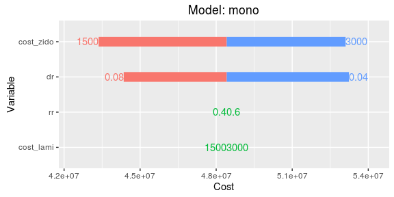

```r
plot(res,
     model = "mono",
     result = "cost",
     type = "simple")
```

On the other hand the `comb` model cost is sensitive to all 4 parameters.

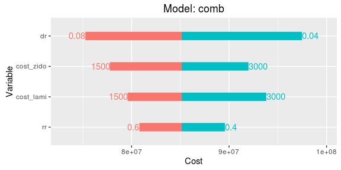

```r
plot(res,
     model = "comb",
     result = "cost",
     type = "simple")
```

And its effectiveness is sensitive to `rr`

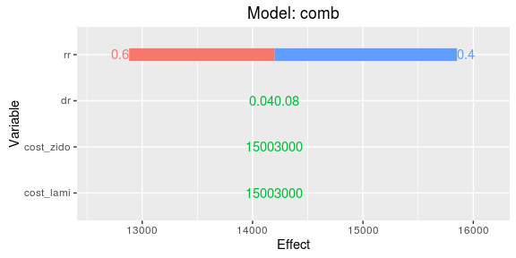

```r
plot(res,
     model = "comb",
     result = "effect",
     type = "simple")
```

The difference plot (`type = "difference"`) displays the difference between the specified model `comb` and the reference model `mono`.

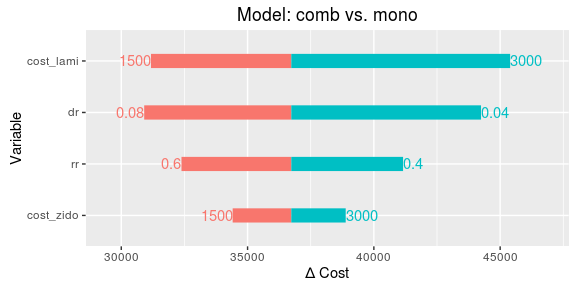

```r
plot(res,
     model = "comb",
     result = "cost",
     type = "difference")
```

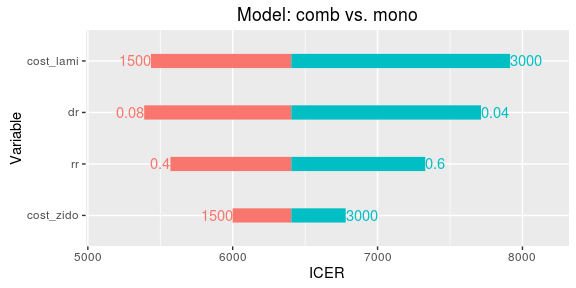

```r
plot(res,
     model = "comb",
     result = "icer",
     type = "difference")
```